# Assignment: Among Site (Beta) Diversity

```r
# We can now construct a spatial model using only the selected PCNM axes.
space.mod = model.matrix(~ PCNM2 + PCNM3 + PCNM5 + PCNM1 +
PCNM13 + PCNM16 + PCNM6, doubs.space)[,-1]
# First conduct constrained ordinations
doubs.total.env = dbrda(fish.db ~ env.mod)
doubs.total.space = dbrda(fish.db ~ space.mod)
# Next construct partial constrained ordinations
doubs.env.cond.space = dbrda(fish.db ~ env.mod + Condition(space.mod))
doubs.space.cond.env = dbrda(fish.db ~ space.mod + Condition(env.mod))
# Next test for significance of the dbRDA fractions.
permutest(doubs.env.cond.space, permutations = 999)
```

```
##
## Permutation test for dbrda
##
## Permutation: free
## Number of permutations: 999
##
## Call: dbrda(formula = fish.db ~ env.mod + Condition(space.mod))
## Permutation test for all constrained eigenvalues
## Pseudo-F:     4.423025 (with 3, 18 Degrees of Freedom)
## Significance:     0.001
```

```r
permutest(doubs.space.cond.env, permutations = 999)
```

```
##
## Permutation test for dbrda
##
## Permutation: free
## Number of permutations: 999
##
## Call: dbrda(formula = fish.db ~ space.mod + Condition(env.mod))
## Permutation test for all constrained eigenvalues
## Pseudo-F:     4.174109 (with 7, 18 Degrees of Freedom)
## Significance:     0.001
```

```r
permutest(doubs.total.env, permutations = 999)
```

```
##
## Permutation test for dbrda
##
## Permutation: free
## Number of permutations: 999
##
## Call: dbrda(formula = fish.db ~ env.mod)
## Permutation test for all constrained eigenvalues
## Pseudo-F:     10.2619 (with 3, 25 Degrees of Freedom)
## Significance:     0.001
```

```r
permutest(doubs.total.space, permutations = 999)
```

```
##
## Permutation test for dbrda
##
## Permutation: free
## Number of permutations: 999
##
## Call: dbrda(formula = fish.db ~ space.mod)
## Permutation test for all constrained eigenvalues
## Pseudo-F:     7.108896 (with 7, 21 Degrees of Freedom)
## Significance:     0.001
```

```r
dev.off
```

[output not shown]

```r
# Using the built-in varpart() function
doubs.varpart = varpart(fish.db, env.mod, space.mod)
doubs.varpart
```

```
##
## Partition of squared Bray distance in dbRDA
##
## Call: varpart(Y = fish.db, X = env.mod, space.mod)
##
## Explanatory tables:
## X1:  env.mod
## X2:  space.mod
##
## No. of explanatory tables: 2
## Total variation (SS): 6.7621
## No. of observations: 29
##
## Partition table:
##                      Df R.squared Adj.R.squared Testable
## [a+b] = X1            3   0.55186       0.49808     TRUE
## [b+c] = X2            7   0.70323       0.60431     TRUE
## [a+b+c] = X1+X2      10   0.82917       0.73426     TRUE
## Individual fractions
## [a] = X1|X2           3                 0.12995     TRUE
## [b]                   0                 0.36813    FALSE
## [c] = X2|X1           7                 0.23618     TRUE
## [d] = Residuals                         0.26574    FALSE
## ---
## Use function 'capscale' to test significance of fractions of interest
```

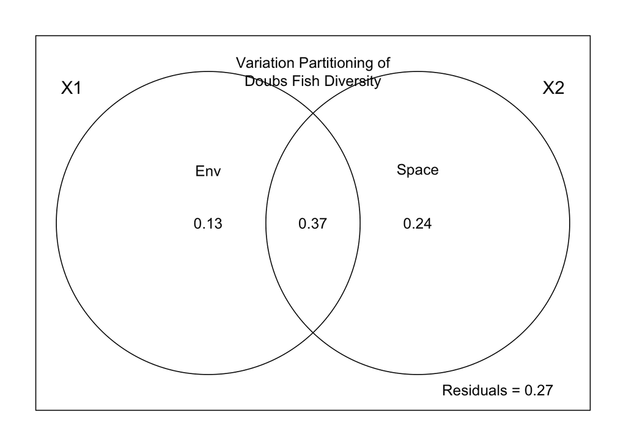

```r
par(mar = c(2,2,2,2))
plot(doubs.varpart)
text(1, 0.25, "Space")
text(0, 0.25, "Env")
mtext("Variation Partitioning of\nDoubs Fish Diversity", side = 3, line = -3)
```

*Question 11*: Interpret the variation partitioning results.

> *Answer 11*: Around 13% of the variation in fish diversity in the Doubs River can be attributed to environmental variables, most notably, biological oxygen demand and dissolved oxygen & nitrate concentrations. Almost a quarter of the variation in fish diversity (24%) can be attributed to changes in spatial positionalong the river. Spatial & environmental factors explain about 37% of the variation in fish species diversity. Around 27% of the variaiton is unexplained. Spatial position explains ~2x more than environmental variables when assessed independently, however, they explain the most variation (37%) together. It seems as though spatial and environmental variation together are driving fish community strucutre in the River Doubs.

## SYNTHESIS

Load the dataset you are using for your project. Perform an ordination to visualize your dataset. Using this ordination, develop some hypotheses relevant to $\beta$-diversity and identify the appropriate tools you would use to test them.

```r
# Loading required packages
require("dplyr")
```

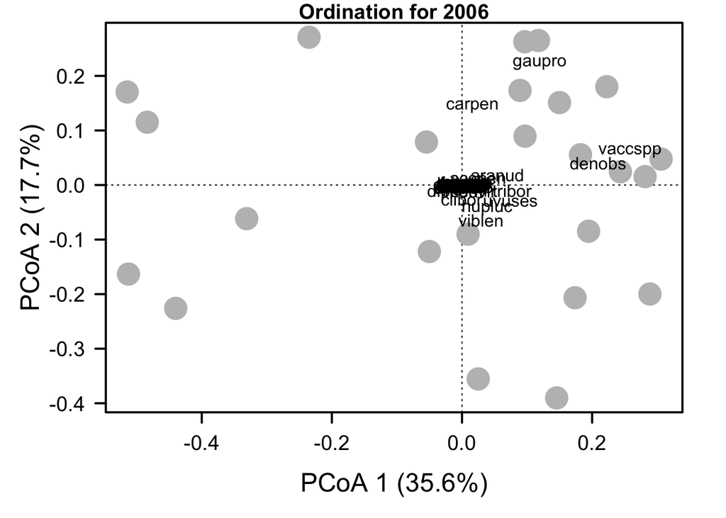

```r
# Reading in tree diversity data
plant = read.csv("/Users/bhbeidler/GitHub/QB2017_DivPro/Data/HF_plants.csv")

# Subsetting the data into the different years
plant_06 = filter(plant, year == 2006)
plant_07 = filter(plant, year == 2007)
plant_08 = filter(plant, year == 2008)
plant_09 = filter(plant, year == 2009)

# Separating out the treatments from the site by species matricies
plant_06_sbys = plant_06[ ,4:43]
plant_07_sbys = plant_07[ ,4:43]
plant_08_sbys = plant_08[ ,4:43]
plant_09_sbys = plant_09[ ,4:43]

# Ordination

# construct a resemblance matrix based on Bray-Curtis Distance ("plant_2006.db") for 2006
plant_06.db = vegdist(plant_06_sbys, method = "bray", upper = TRUE, diag = TRUE)
# Perform a Principal Coordinates Analysis to visualize beta-diversity
plant_06.pcoa = cmdscale(plant_06.db, eig = TRUE, k = 3)

# Calculate the variation explained by the first three axes in your ordination
explainvar1 = round(plant_06.pcoa$eig[1] / sum(plant_06.pcoa$eig), 3) * 100
explainvar2 = round(plant_06.pcoa$eig[2] / sum(plant_06.pcoa$eig), 3) * 100
explainvar3 = round(plant_06.pcoa$eig[3] / sum(plant_06.pcoa$eig), 3) * 100
sum.eig = sum(explainvar1, explainvar2, explainvar3)


# plot the PCoA ordination
# Define Plot Parameters
par(mar = c(5, 5, 1, 2) + 0.1)
# Initiate Plot
plot(plant_06.pcoa$points[ ,1], plant_06.pcoa$points[ ,2],
xlab = paste("PCoA 1 (", explainvar1, "%)", sep = ""),
ylab = paste("PCoA 2 (", explainvar2, "%)", sep = ""),
main = "Ordination for 2006",
pch = 16, cex = 2.0, type = "n", cex.lab = 1.5, cex.axis = 1.2, axes = FALSE)
# Add Axes
axis(side = 1, labels = T, lwd.ticks = 2, cex.axis = 1.2, las = 1)
axis(side = 2, labels = T, lwd.ticks = 2, cex.axis = 1.2, las = 1)
abline(h = 0, v = 0, lty = 3)
box(lwd = 2)

# Add Points & Labels
points(plant_06.pcoa$points[ ,1], plant_06.pcoa$points[ ,2],
pch = 16, cex = 3, bg = "gray", col = "gray")
text(plant_06.pcoa$points[ ,1], plant_06.pcoa$points[ ,2],
labels = row.names(plant_06.pcoa$points))

# Identify influential species
# First we calculate the relative abundances of each species at each site
plant_06REL = plant_06_sbys
for(i in 1:nrow(plant_06_sbys )){
plant_06REL[i, ] = plant_06_sbys [i, ] / sum(plant_06_sbys [i, ])
}
# Now, we use this information to calculate and add species scores
plant_06.pcoa= add.spec.scores(plant_06.pcoa,plant_06REL,method = "pcoa.scores")
text(plant_06.pcoa$cproj[ ,1], plant_06.pcoa$cproj[ ,2],
labels = row.names(plant_06.pcoa$cproj), col = "black")
```

```r
# Hypothesis Testing
# H1: Soil treatment (either warming or N fertilization) influenced beta diversity during 2006.

# Multivariate Procedures for Categorical designs

# There are 40 tree species. For each year and each treatment there are 6 sites. Treatments include: 1=control, 2=warm, 3=nitrogen, 4=warm/nitrogen
# Create "Factors" vector for categorizing soil treatments
soil_treat = as.factor(plant_06[ ,3])

# Run PERMANOVA with adonis function
PERMA.06 = adonis(plant_06_sbys ~ soil_treat, method = "bray", permutations = 999)
PERMA.07 = adonis(plant_07_sbys ~ soil_treat, method = "bray", permutations = 999)
PERMA.08 = adonis(plant_08_sbys ~ soil_treat, method = "bray", permutations = 999)
PERMA.09 = adonis(plant_09_sbys ~ soil_treat, method = "bray", permutations = 999)

PERMA.06
```

```
##
## Call:
## adonis(formula = plant_06_sbys ~ soil_treat, permutations = 999,      method = "bray")
##
## Permutation: free
## Number of permutations: 999
##
## Terms added sequentially (first to last)
##
##            Df SumsOfSqs  MeanSqs F.Model      R2 Pr(>F)
## soil_treat  3    0.2292 0.076403 0.34078 0.04863  0.999
## Residuals  20    4.4840 0.224198         0.95137
## Total      23    4.7132                  1.00000
```

```r
PERMA.07
```

```
##
## Call:
## adonis(formula = plant_07_sbys ~ soil_treat, permutations = 999,      method = "bray")
##
## Permutation: free
## Number of permutations: 999
##
## Terms added sequentially (first to last)
##
##            Df SumsOfSqs  MeanSqs F.Model      R2 Pr(>F)
## soil_treat  3    0.2948 0.098282 0.40013 0.05662  0.999
## Residuals  20    4.9125 0.245626         0.94338
## Total      23    5.2074                  1.00000
```

```r
PERMA.08
```

```
##
## Call:
## adonis(formula = plant_08_sbys ~ soil_treat, permutations = 999,      method = "bray")
##
## Permutation: free
## Number of permutations: 999
##
## Terms added sequentially (first to last)
##
##            Df SumsOfSqs MeanSqs F.Model      R2 Pr(>F)
## soil_treat  3    0.4008 0.13361 0.59238 0.08161  0.938
## Residuals  20    4.5110 0.22555         0.91839
## Total      23    4.9118                 1.00000
```

```r
PERMA.09
```

```
##
## Call:
## adonis(formula = plant_09_sbys ~ soil_treat, permutations = 999,      method = "bray")
##
## Permutation: free
## Number of permutations: 999
##
## Terms added sequentially (first to last)
##
##            Df SumsOfSqs MeanSqs F.Model      R2 Pr(>F)
## soil_treat  3    0.5218 0.17393 0.85599 0.11379  0.664
## Residuals  20    4.0637 0.20319         0.88621
## Total      23    4.5855                 1.00000
```

> *Answer Synthesis*: Testing to see if the warming or N treatments influence beta diversity. I used a PERMANOVA to test the hypothesis that tree community composition varies with soil treatment. There was no siginificant effect of soil treatment on beta diversity for any of the years. To perform the PERMANOVA I had to subset the data into the different years. To test for the effects of both time and soil treatments on tree community composition we could perform a RDA- partitioning the variance between treatments and time. The study may have been too short to capture any changes in diversity. There is also a companion dataset for this study that looks at ant diversity in the same plots over the same time period. The next step will be to look at ant diversity in addition to tree diversity.

[output not shown]